# Visualizing Trends

## Time Series Decomposition

Load in the data:

```r
tmsr <- read_csv("tmsr.csv")
```

For simple time series, a line plot is sufficient.

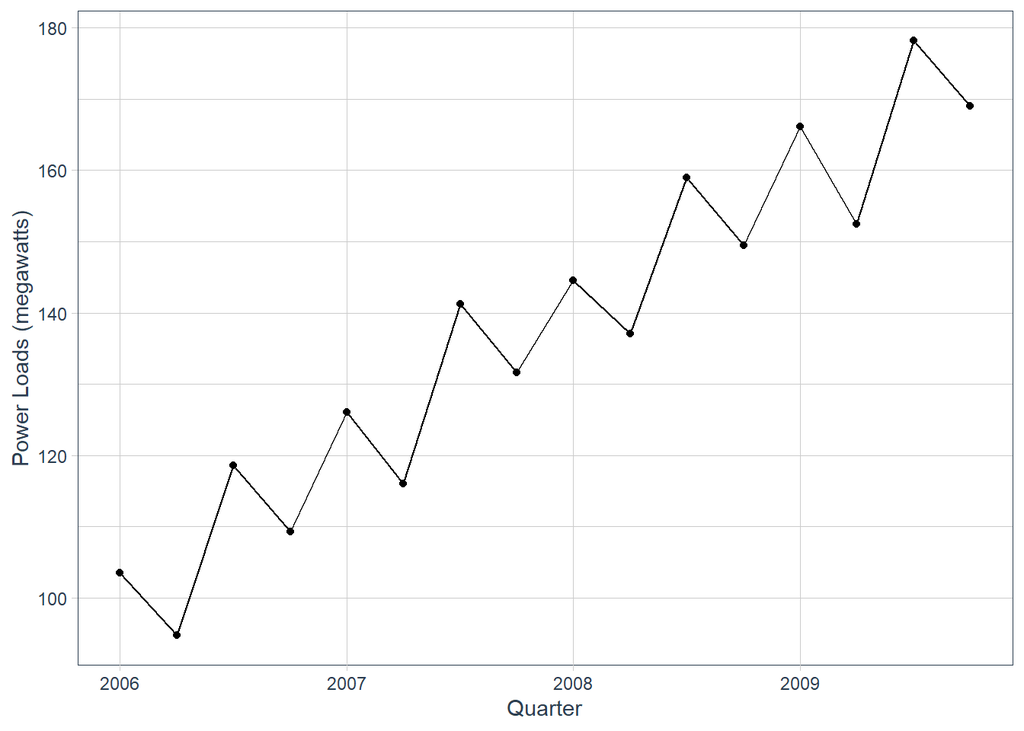

```r
tmsr |>
ggplot(mapping = aes(x = Quarter, y = PowerLoad)) +
  geom_point() +
  geom_line() +
  xlab("Quarter") + ylab("Power Loads (megawatts)") +
  theme_tq()
```

### Moving Averages

To look at trend using the moving average we must identify the number of time points we want to average over. There is an option to use a built in fucntion but it takes the previous `n` points not the points before and after.

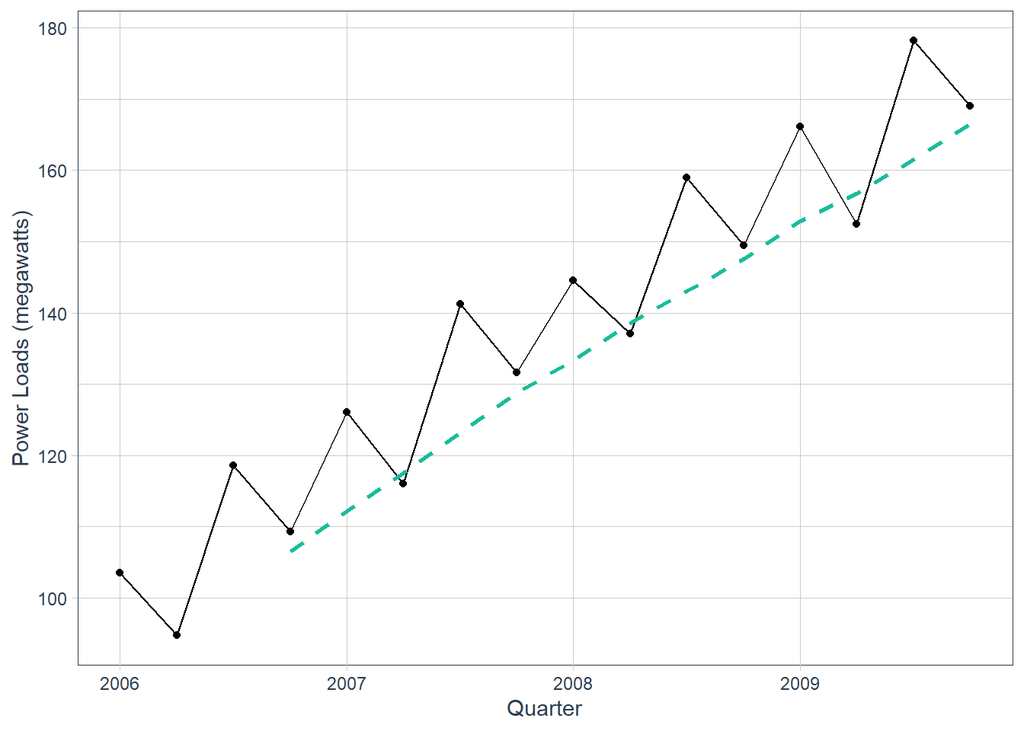

```r
tmsr |>
  ggplot(mapping = aes(x = Quarter, y = PowerLoad)) +
  geom_point() + geom_line() +
  xlab("Quarter") + ylab("Power Loads (megawatts)") +
  theme_tq() +
  geom_ma(ma_fun = SMA, n = 4,
          linewidth = 1, color = "#1ABC9C") #moving average method over 4 time points
```

Here is how a linear regression model compares to a moving average model:

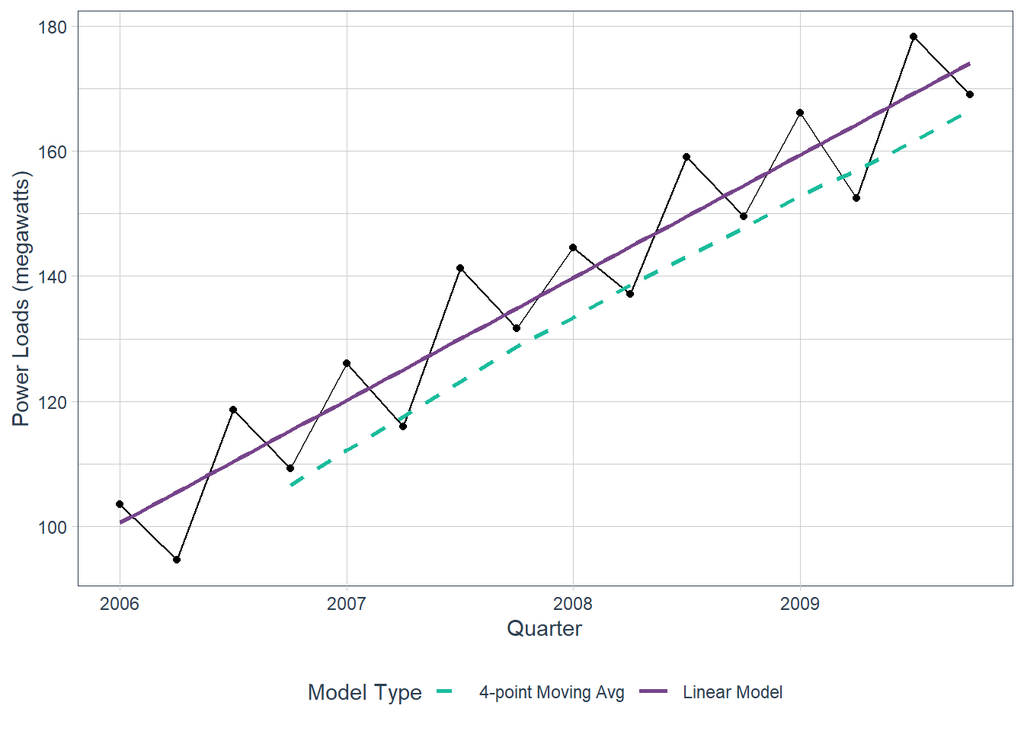

```r
tmsr |>
  ggplot(mapping = aes(x = Quarter, y = PowerLoad)) +
  geom_point() + geom_line() +
  xlab("Quarter") + ylab("Power Loads (megawatts)") +
  theme_tq() +
  geom_ma(ma_fun = SMA, n = 4, linewidth = 1,
          aes(color = "#1ABC9C")) +
  geom_smooth(method = "lm", aes(color = "#76448A"),
              se = FALSE) +
  scale_color_identity(guide = "legend",
                       name = "Model Type",
                       breaks = c("#1ABC9C","#76448A"),
                       labels = c("4-point Moving Avg",
                                  "Linear Model"))
```

To find the coefficients of the linear regression we must use the `lm` function and extract the information for the slope and intercept.

```r
model <- lm(PowerLoad ~ Quarter, data = tmsr)
coef(model)
```

```
 (Intercept)      Quarter
-39211.13824     19.59706
```

```r
#predict(model)
```

## Plotting Time Series

Here is a more complex set of time series data.

```r
beer <- read_csv("beer_sales.csv")
```

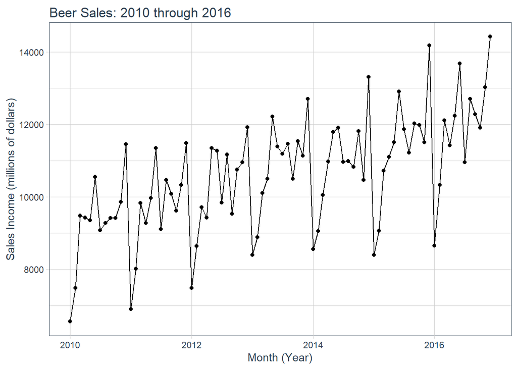

```r
beer |>
  ggplot(aes(x = date, y = price)) +
  geom_line() +
  geom_point() +
  labs(title = "Beer Sales: 2010 through 2016",
       y = "Sales Income (millions of dollars)",
       x = "Month (Year)") +
  theme_tq()
```

## Moving Average

Here is the moving average for the beer data - why did we choose 12 points for our average?

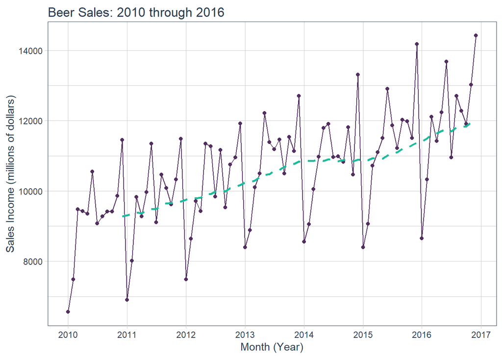

```r
beer |>
  ggplot(aes(x = date, y = price)) +
  geom_line(color = "#512E5F") +
  geom_point(color = "#512E5F") +
  labs(title = "Beer Sales: 2010 through 2016",
       y = "Sales Income (millions of dollars)",
       x = "Month (Year)") +
  theme_tq() +
  geom_ma(ma_fun = SMA, n = 12, linewidth = 1, color = "#1ABC9C") +
  scale_x_date(date_breaks = "1 year", date_labels = "%Y")
```

## Time Series Decomposition

Here is the time series decomposition for the beer data. We have to actually preprocess the data first to calculate the values that will be plotted for the decomposition and then we are basically just making line graphs.

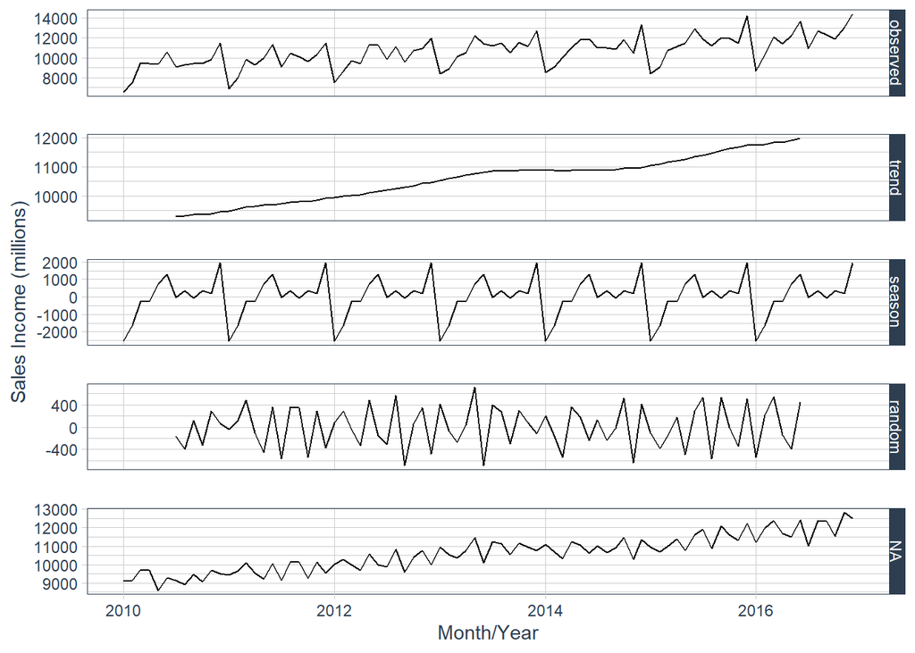

```r
beer_ts <- tk_ts(beer, start = 2010, freq = 12, silent = TRUE)

fit_decomposed <- beer_ts |>
    decompose()

sw_tidy_decomp(fit_decomposed, timetk_idx = TRUE) |>
  pivot_longer(-1, names_to = "decomposition", values_to = "timeseries") |>
  mutate(decomposition = factor(decomposition,
                                levels = c("observed",
                                           "trend",
                                          "season",
                                          "season_adj",
                                          "random"))) |>
  ggplot(aes(x = index, y = timeseries)) +
  geom_line() +
  facet_grid(decomposition ~ ., scales = "free_y") +
  labs(x = "Month/Year", y = "Sales Income (millions)") +
  theme_tq()
```

## LOESS and Spline Regression

Here are examples of simple linear regression, LOESS regression, and Spline Regression.

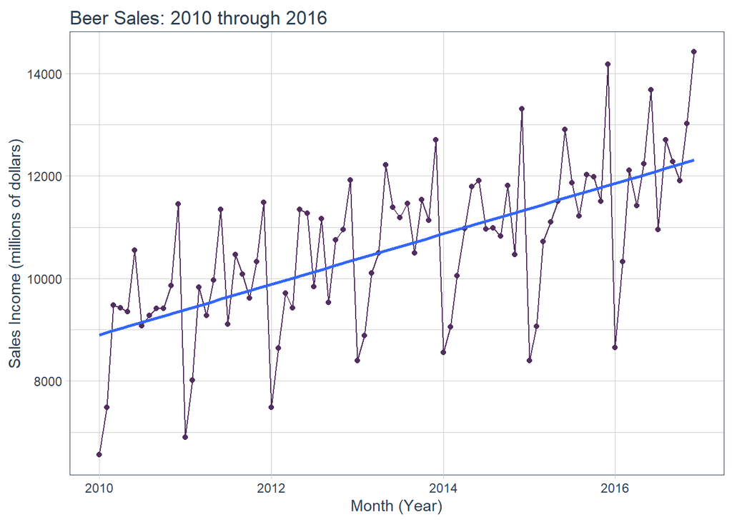

```r
#SLR "linear mode" method in geom_smooth
beer |>
  ggplot(aes(x = date, y = price)) +
  geom_line(color = "#512E5F") +
  geom_point(color = "#512E5F") +
  labs(title = "Beer Sales: 2010 through 2016",
       y = "Sales Income (millions of dollars)",
       x = "Month (Year)") +
  theme_tq() +
  geom_smooth(method = "lm", se = FALSE)
```

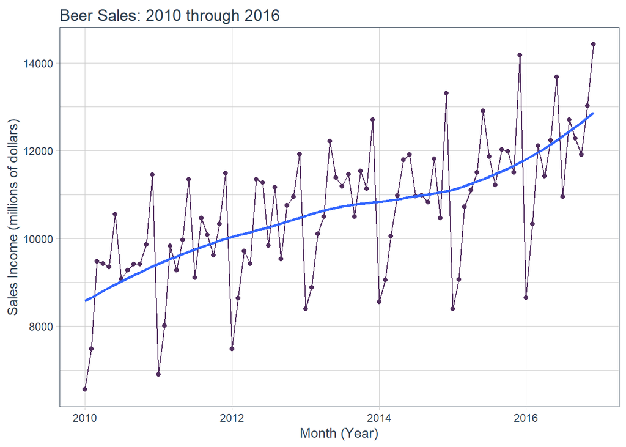

```r
#loess method in geom_smooth
beer |>
  ggplot(aes(x = date, y = price)) +
  geom_line(color = "#512E5F") +
  geom_point(color = "#512E5F") +
  labs(title = "Beer Sales: 2010 through 2016",
       y = "Sales Income (millions of dollars)",
       x = "Month (Year)") +
  theme_tq() +
  geom_smooth(method = "loess", se = FALSE)
```

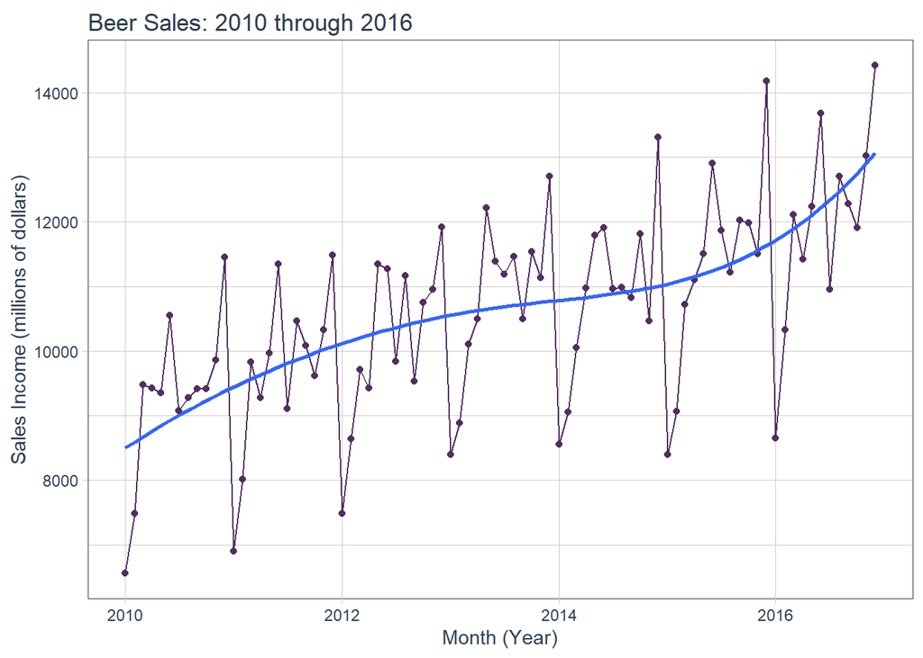

```r
#spline method: lm in geom_smooth, formula includes spline package function
beer |>
  ggplot(aes(x = date, y = price)) +
  geom_line(color = "#512E5F") +
  geom_point(color = "#512E5F") +
  labs(title = "Beer Sales: 2010 through 2016",
       y = "Sales Income (millions of dollars)",
       x = "Month (Year)") +
  theme_tq() +
  geom_smooth(method = lm,
              formula = y ~ splines::bs(x, 4),
              se = FALSE)
```

# Least Squares Regression

## Simple Linear Regression

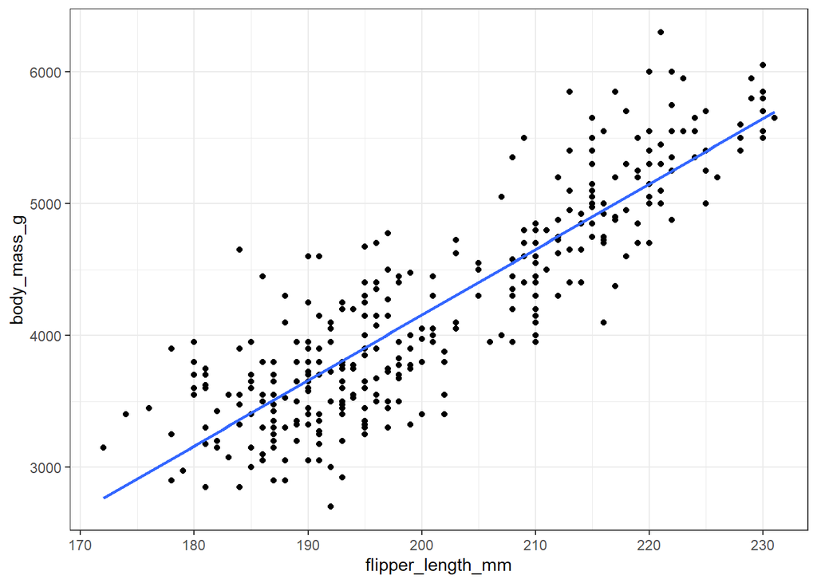

```r
library(palmerpenguins)

data(penguins)

penguins |>
  #global aesthetics, apply to both points and regression lines
  ggplot(aes(x = flipper_length_mm,
             y = body_mass_g)) +
  geom_point() +
  geom_smooth(method = lm, se = FALSE) +
  theme_bw()
```

## Multiple Linear Regression (one categorical variable added)

We can add multiple regression lines to a plot!

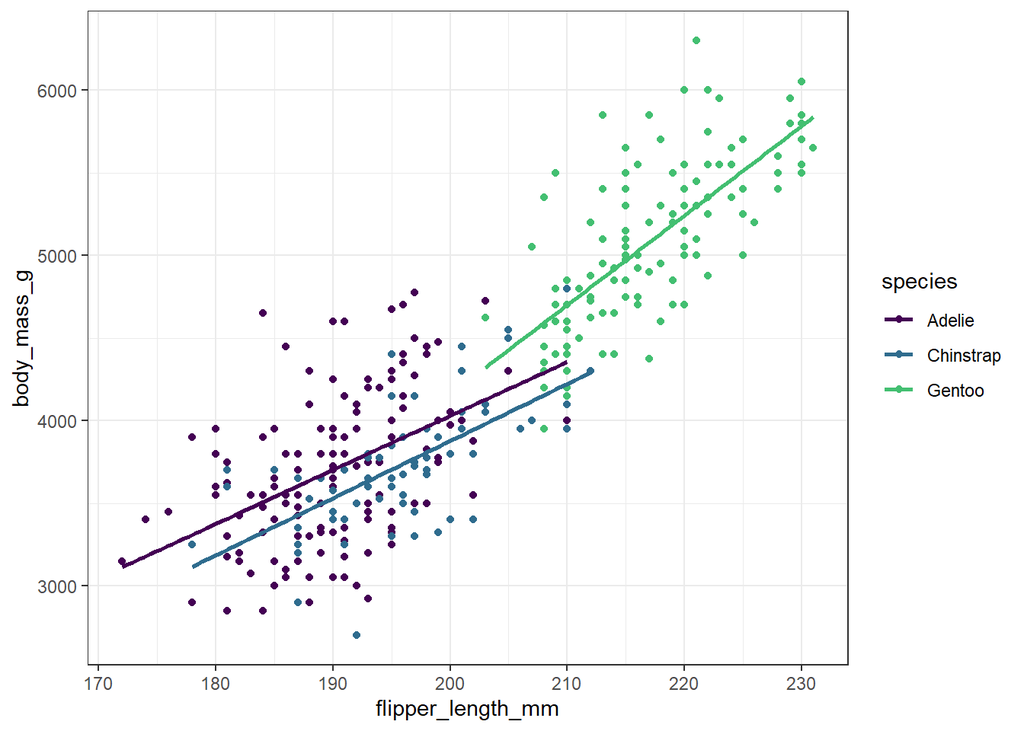

```r
library(palmerpenguins)

data(penguins)

penguins |>
  drop_na(sex) |>
  #only needed to add color = species
  ggplot(aes(x = flipper_length_mm,
             y = body_mass_g,
             color = species)) +
  geom_point() +
  geom_smooth(method = lm, se = FALSE) +
  scale_color_viridis_d(end = 0.7) +
  theme_bw()
```

### Multiple Linear Regression with 2 categorical variables

We can add multiple regression lines to a plot!

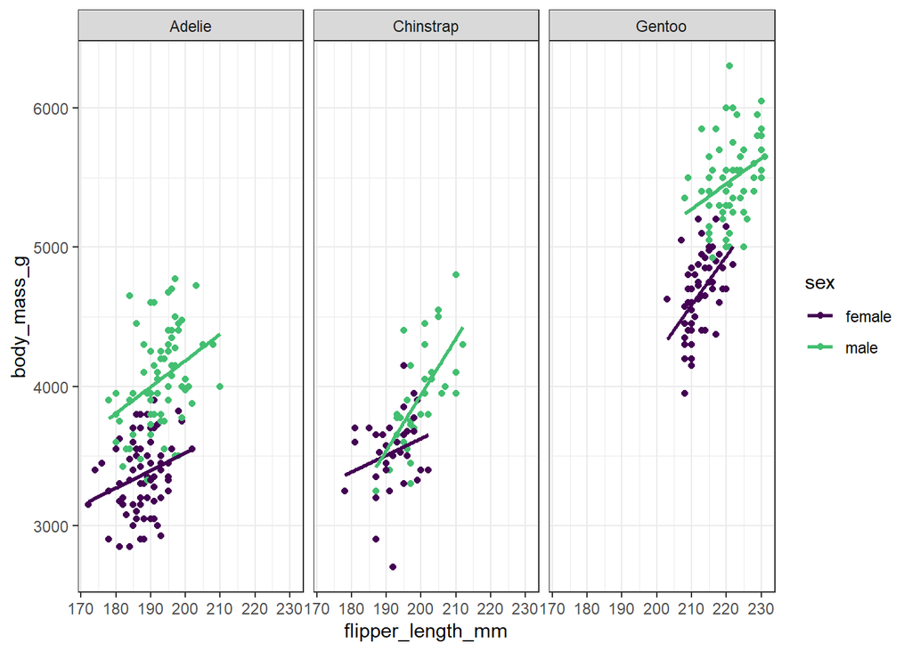

```r
library(palmerpenguins)
data(penguins)

penguins |>
  drop_na(sex) |>
  #global aesthetics, apply to both points and regression lines
  ggplot(aes(x = flipper_length_mm,
             y = body_mass_g,
             color = sex)) +
  geom_point() +
  geom_smooth(method = lm, se = FALSE) +
  scale_color_viridis_d(end = 0.7) +
  facet_grid(. ~ species) +
  theme_bw()
```

## Curved Relationships

### Quadratic Trends

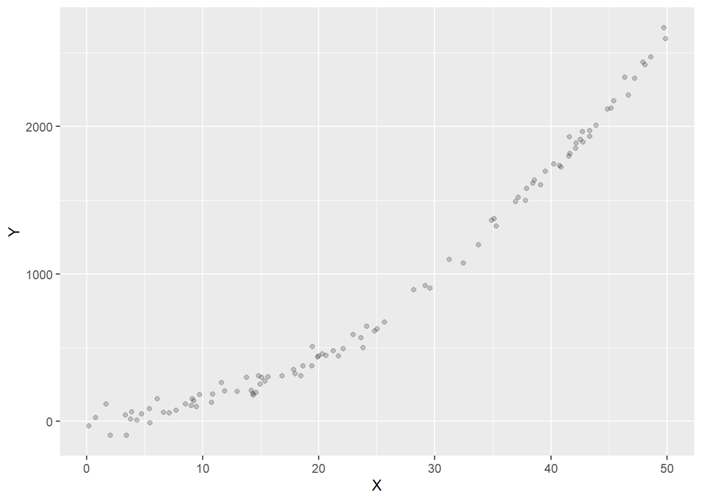

```r
#Randomly generate data points that follow a quadratic trend
x <- runif(100, 0, 50)
y <- 4 + x^2+2*x + rnorm(100,0,50)

dataxy <- data.frame(X=x, Y=y)

#first just plot the data points
dataxy |>
  ggplot(mapping=aes(x=X,y=Y)) +
  geom_point(alpha=0.2)
```

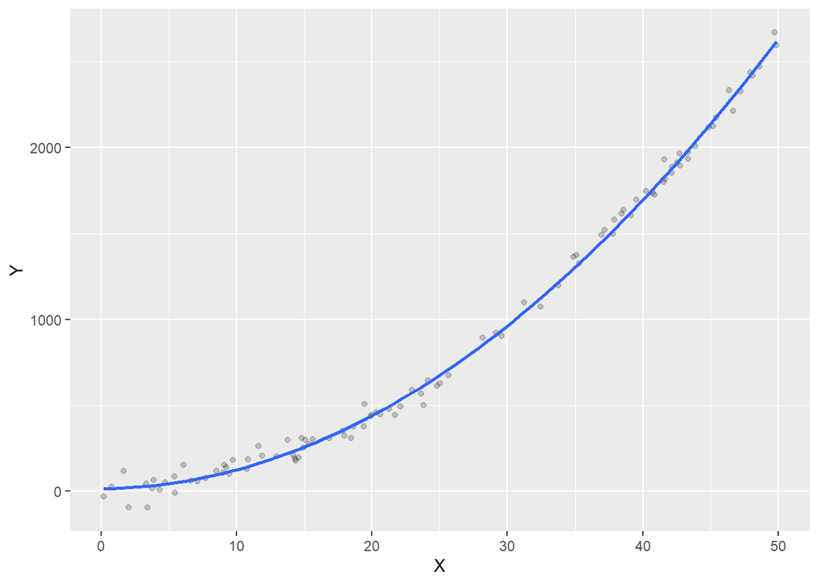

```r
#now add the quadratic trend line using a 2nd-degree polynomial
dataxy |>
  ggplot(mapping=aes(x=X,y=Y)) +
  geom_point(alpha=0.2) +
  geom_smooth(method="gam" , formula=y~poly(x,2), se=FALSE)
```

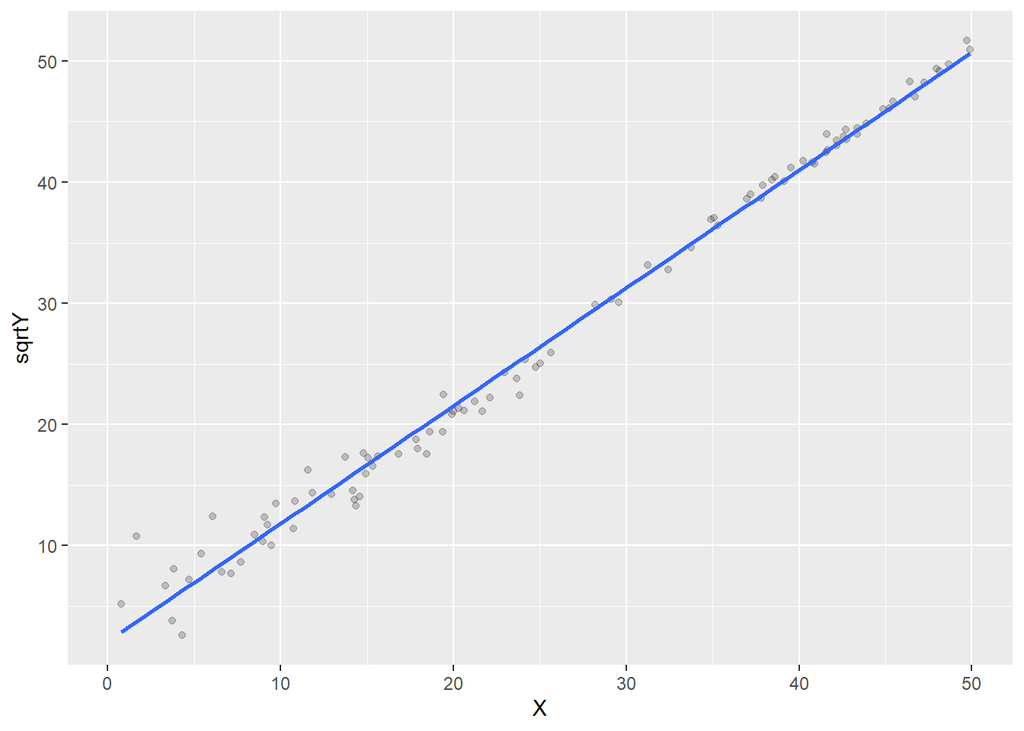

```r
#instead of graphing a quadratic trend, do a square root transformation on y and fit simple linear regression
dataxy |>
  mutate(sqrtY=sqrt(Y)) |>
  ggplot(mapping=aes(x=X,y=sqrtY)) +
  geom_point(alpha=0.2)+
  geom_smooth(method="lm", se=FALSE)
```

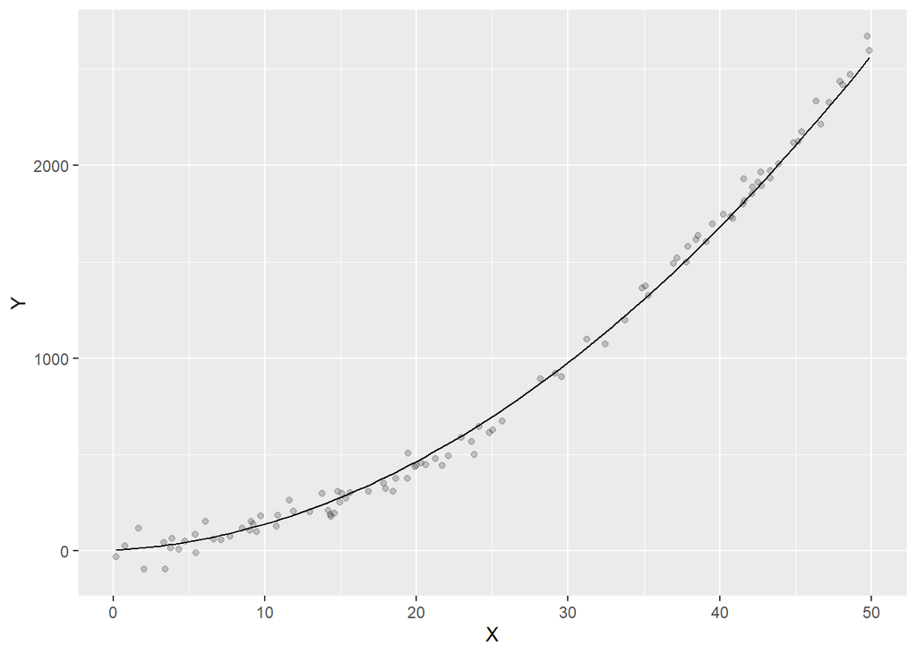

```r
dataxy |>
  mutate(sqrtY=sqrt(Y)) -> dxysy

#fit a linear model of sqrt(y) modeled by x

model<-lm(sqrtY~X, data=dxysy)

#extract the model coefficients (intercept and slope)
ab<-coef(model)

#directly graph the regression equation using stat_function and the coefficients (stored in "ab")
dataxy |>
  ggplot(mapping=aes(x=X,y=Y)) +
  geom_point(alpha=0.2)+
  stat_function(fun = function(x) (ab[1]+ab[2]*x)^2)
```

### Eponential or Logarithmic Trends

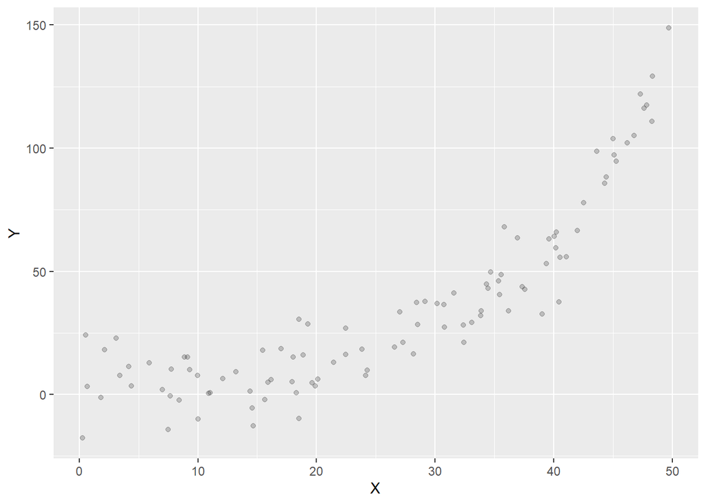

```r
##Exponential or Logorithm
x <- runif(100, 0, 50)
y <- 4 + exp(x/10) + rnorm(100,0,10)

dataxy <- data.frame(X=x, Y=y)

#first just plot the data points
dataxy |>
  ggplot(mapping=aes(x=X,y=Y)) +
  geom_point(alpha=0.2)
```

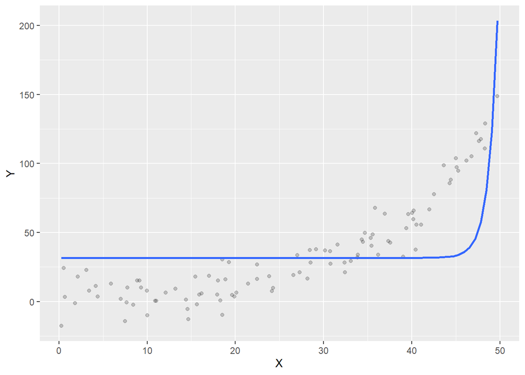

```r
#fit the curve
dataxy |>
  ggplot(mapping=aes(x=X,y=Y)) +
  geom_point(alpha=0.2)+
  geom_smooth(method="glm" , formula=y~exp(x), se=FALSE)
```

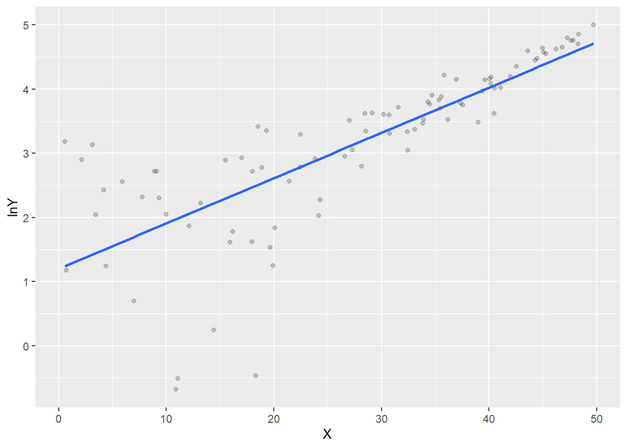

```r
#do log tranformation of y
dataxy |>
  mutate(lnY=log(Y)) |>
  ggplot(mapping=aes(x=X,y=lnY)) +
  geom_point(alpha=0.2)+
  geom_smooth(method="lm", se=FALSE)
```

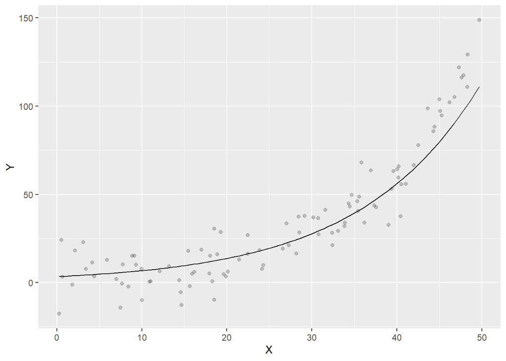

```r
#store the transformed variable
dataxy |>
  mutate(lnY=log(Y)) -> dxylny

#fit the SLR model on log transformed y, and extract coefficients
model<-lm(lnY~X, data=dxylny)
ab<-coef(model)

#directly plot using coefficients
dataxy |>
  ggplot(mapping=aes(x=X,y=Y)) +
  geom_point(alpha=0.2)+
  stat_function(fun = function(x) exp(ab[1]+ab[2]*x))
```